# Logbook_Jasper

```r
gsea_kegg_2 <- gseKEGG(
  geneList = sol_gen,
  organism = "mmu",
  pvalueCutoff = 0.05,
  seed= 1
)
```

```
## using 'fgsea' for GSEA analysis, please cite Korotkevich et al (2019).
```

```
## preparing geneSet collections...
```

```
## GSEA analysis...
```

```
## leading edge analysis...
```

```
## done...
```

```r
head(gsea_kegg_2)
```

```
##                ID                 Description setSize enrichmentScore       NES
## mmu04657 mmu04657     IL-17 signaling pathway      61      -0.5251050 -1.923643
## mmu04062 mmu04062 Chemokine signaling pathway     107      -0.4355532 -1.771368
##                pvalue   p.adjust     qvalue rank                   leading_edge
## mmu04657 0.0002390181 0.04389758 0.04048433 2013 tags=38%, list=17%, signal=31%
## mmu04062 0.0002652422 0.04389758 0.04048433 2954 tags=39%, list=26%, signal=29%
##                                                                                                                                                                                                                                                              core_enrichment
## mmu04657                                                                                                                        20306/26419/17386/20296/12370/71609/59008/68652/14082/22030/22031/56480/12675/18033/14825/19225/103213/239114/56489/20297/330122/20311/16819
## mmu04062 56637/18709/12929/14772/20848/26417/11848/14702/109905/16653…
```

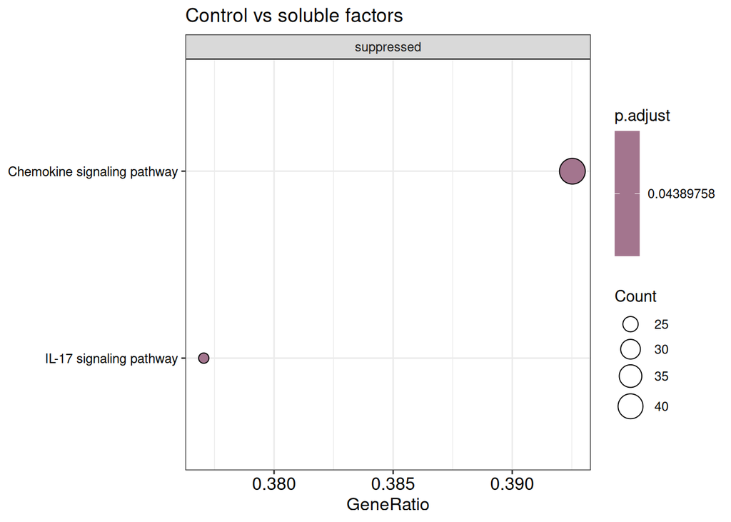

```r
dotplot(gsea_kegg_2, showCategory=5, split=".sign") + facet_grid(.~.sign) + theme(axis.text.y = element_text(size = 9))+ labs(title = 'Control vs soluble factors')
```

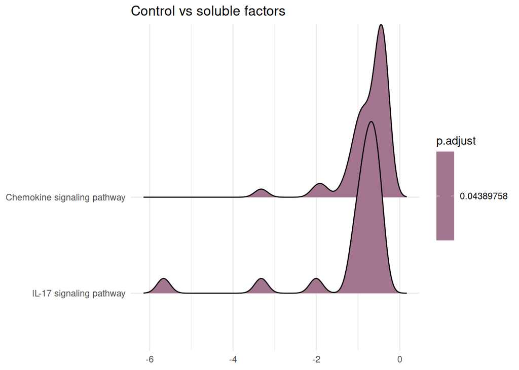

```r
ridgeplot(gsea_kegg_2, showCategory = 10, fill = "p.adjust")+ theme_minimal()+ labs(title = 'Control vs soluble factors')
```

Conclusie – Pathwaysuppressie in SF-conditie

Aan de hand van de GSEA-analyse (dotplot en ridgeplot) van de vergelijking tussen control en soluble factors (SF’s), zijn twee KEGG-pathways geïdentificeerd die significant onderdrukt zijn in de SF-conditie. Deze pathways vielen op door hun lage p-waarden (p.adjust), consistente negatieve genexpressie en duidelijke suppressie:

```
Chemokine signaling pathway – Mus musculus

→ Onderdrukking van genen die betrokken zijn bij immuuncelactivatie en -migratie, wijzend op een remming van ontstekingsprocessen.
IL-17 signaling pathway – Mus musculus

→ IL-17 is cruciaal voor pro-inflammatoire signalering; de sterke onderdrukking van deze route suggereert dat SF’s ontstekingsreacties actief temperen.

De gelijktijdige onderdrukking van deze twee immuun-gerelateerde pathways wijst erop dat SF’s mogelijk een immunosuppressieve werking uitoefenen op          ontvangende cellen. Dit zou kunnen bijdragen aan een verminderde immuunactivatie of ontstekingsremming.
```

```r
terms <- c(
  "Chemokine signaling pathway - Mus musculus (house mouse)",
  "IL-17 signaling pathway - Mus musculus (house mouse)"
)
gsea_kegg_2@result[gsea_kegg_2@result$Description %in% terms, ]
```

```
##  [1] ID              Description     setSize         enrichmentScore
##  [5] NES             pvalue          p.adjust        qvalue
##  [9] rank            leading_edge    core_enrichment
## <0 rows> (or 0-length row.names)
```

```r
setwd("imgs_trans/control_vs_soluble")
#IL-17 signaling pathway
pathview(
  gene.data = gsea_kegg_2,
  pathway.id = "mmu04657",
  species = "mmu",
  out.suffix = "IL-17"
)
#Chemokine signaling pathway
pathview(
  gene.data = gsea_kegg_2,
  pathway.id = "mmu04062",
  species = "mmu",
  out.suffix = "Chemokine"
)
```

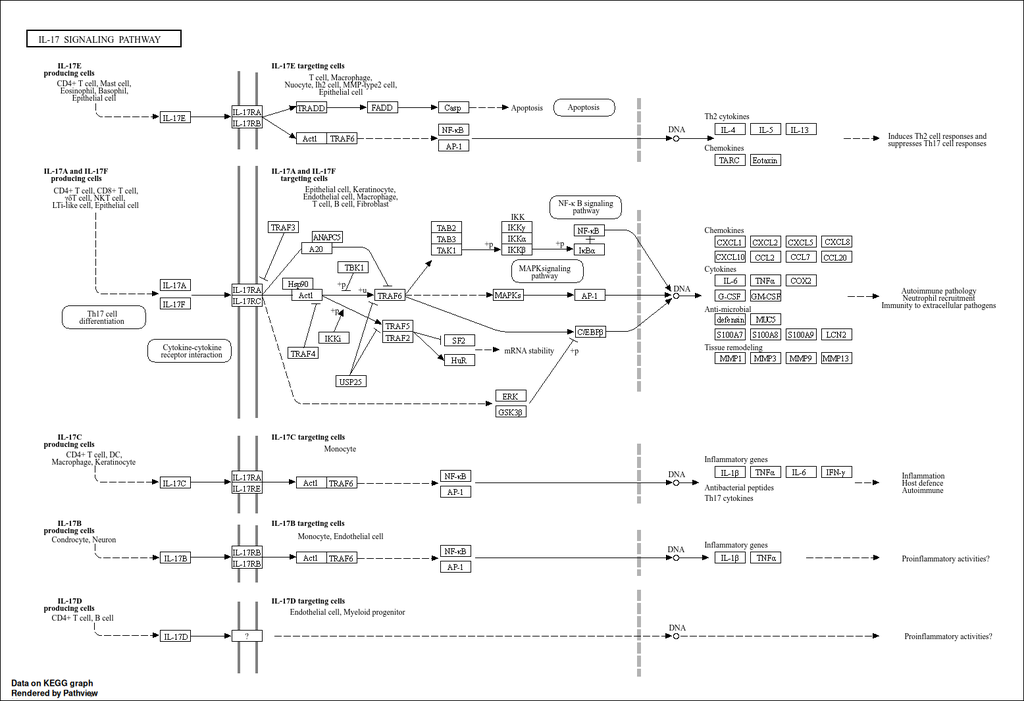

IL-17 signaling pathway

Deze pathway laat zien hoe binding van verschillende IL-17-cytokines leidt tot activatie van downstream signaalroutes, waaronder NF-κB, MAPK en C/EBP. Hierdoor ontstaat een sterke transcriptie van ontstekingsbevorderende genen zoals IL-6, TNF-α en diverse chemokinen. Daarnaast wordt ook de expressie van antimicrobiële eiwitten en matrixmetallo-proteïnasen gestimuleerd, wat duidt op betrokkenheid bij afweer en weefselremodellering. De pathway is dus sterk gericht op het reguleren van ontsteking, immuunactivatie en celrespons op infectie of schade.

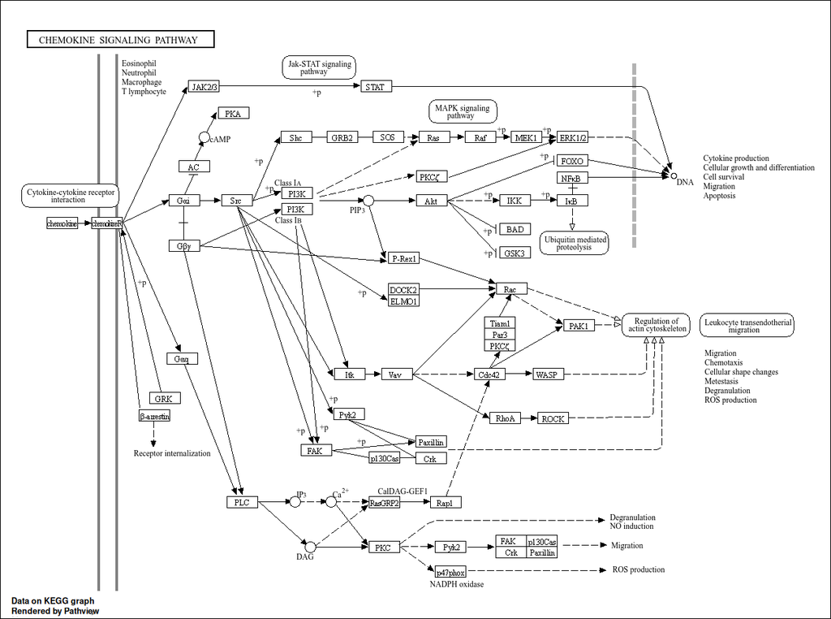

Chemokine signaling pathway

In deze pathway activeert chemokine-receptorbinding meerdere intracellulaire routes zoals PI3K/Akt, MAPK en Rho-GTPase-activiteiten. Deze signalen leiden tot celoverleving, cytokineproductie, actineherstructurering en migratie van immuuncellen. Verder speelt deze pathway een rol bij de regulatie van leukocytenmigratie via het endotheel, ROS-productie en apoptose. De pathway ondersteunt daarmee een brede afstemming van immuuncelgedrag tijdens ontstekingsreacties en immuunresponsen.

```r
df_genes_3 <- data.frame(
  symbol = names(gene_ranks_extra_sol),
  stat = gene_ranks_extra_sol
)
df_mapped_3 <- df_genes_3 %>%
  left_join(
    AnnotationDbi::select(org.Mm.eg.db,
                          keys = df_genes_3$symbol,
                          columns = c("ENTREZID", "SYMBOL"),
                          keytype = "SYMBOL"),
    by = c("symbol" = "SYMBOL")
  ) %>%
  filter(!is.na(ENTREZID))
geneList_3 <- df_mapped_3$stat
names(geneList_3) <- df_mapped_3$ENTREZID
```

```r
gsea_kegg_3 <- gseKEGG(
  geneList = geneList_3,
  organism = "mmu",
  pvalueCutoff = 0.05
)
```

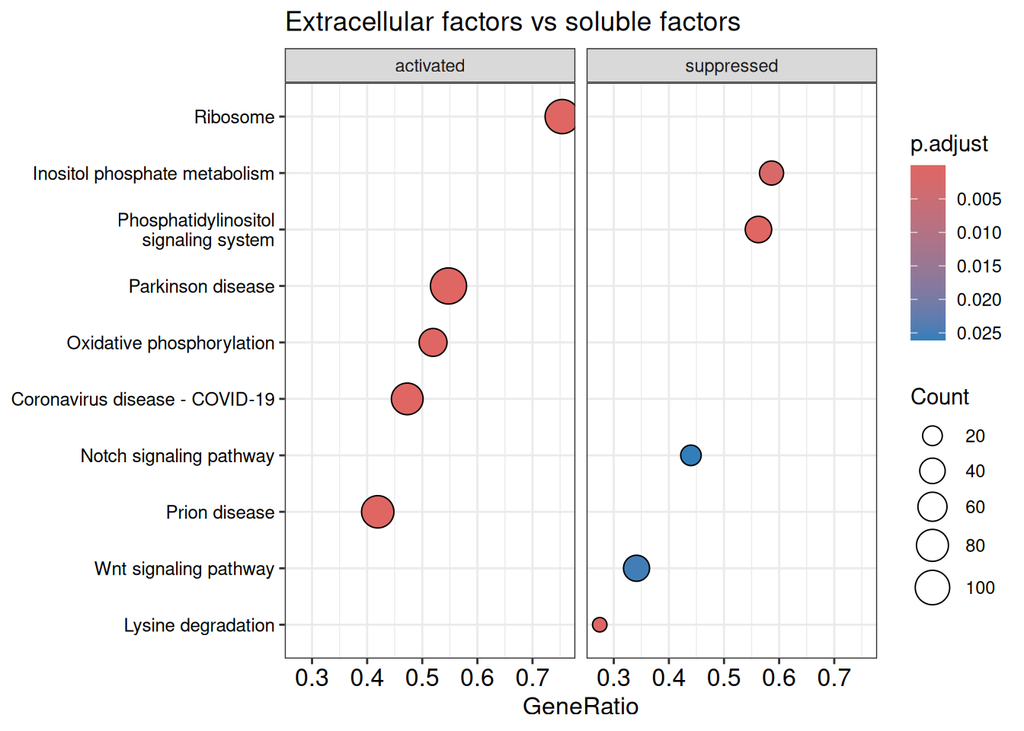

```r
dotplot(gsea_kegg_3, showCategory=5, split=".sign") + facet_grid(.~.sign) + theme(axis.text.y = element_text(size = 9)) + labs(title = 'Extracellular factors vs soluble factors')
```

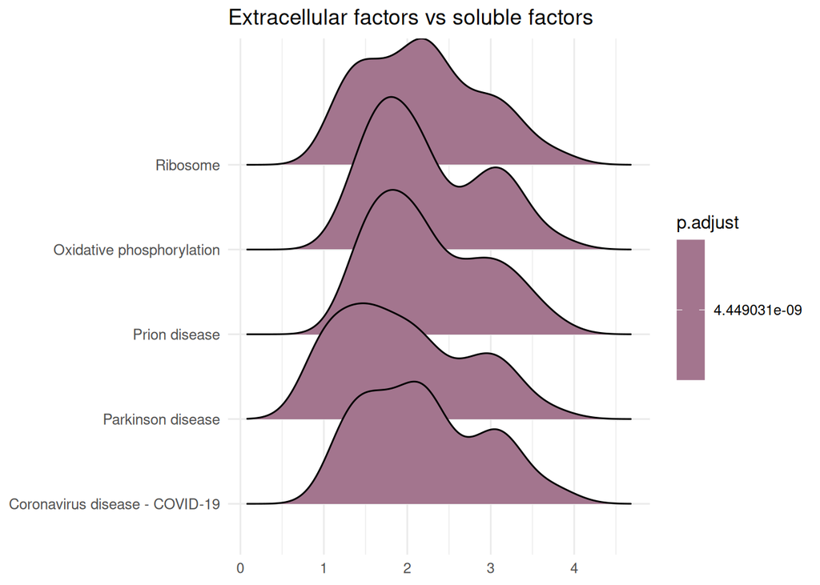

```r
ridgeplot(gsea_kegg_3, showCategory = 5, fill = "p.adjust")+ theme_minimal()+ theme(axis.text.y = element_text(size = 9))+ labs(title = 'Extracellular factors vs soluble factors')
```

Conclusie – Pathwayactivatie in EV t.o.v. SF-conditie

[output not shown]

Om deze bevindingen visueel te onderbouwen worden deze vier pathways geselecteerd voor Pathview-visualisatie op basis van differentiële genexpressie tussen EV- en SF-condities.

```r
terms_best <- c(
  "Ribosome - Mus musculus (house mouse)",
  "Oxidative phosphorylation - Mus musculus (house mouse)",
  "Inositol phosphate metabolism - Mus musculus (house mouse)",
  "Phosphatidylinositol signaling system - Mus musculus (house mouse)"
)
gsea_kegg_3@result[gsea_kegg_3@result$Description %in% terms_best, ]
```

```
##  [1] ID              Description     setSize         enrichmentScore
##  [5] NES             pvalue          p.adjust        qvalue
##  [9] rank            leading_edge    core_enrichment
## <0 rows> (or 0-length row.names)
```

```r
setwd("imgs_trans/extracellular_vs_soluble")

# Ribosome / cytoplasmic translation
pathview(
  gene.data = geneList_3,
  pathway.id = "mmu03010",
  species = "mmu",
  out.suffix = "ribosome"
)
```

```
## Info: Working in directory /home/Jonkerjas/Documents/bioinf/jaar_2/omics/omic_epithelial_cell_repair/Logfiles/imgs_trans/extracellular_vs_soluble
```

```
## Info: Writing image file mmu03010.ribosome.png
```

```r
#Phosphatidylinositol signaling system
pathview(
  gene.data = geneList_3,
  pathway.id = "mmu04070",
  species = "mmu",
  out.suffix = "mito_translation"
)
```

```
## Info: Working in directory /home/Jonkerjas/Documents/bioinf/jaar_2/omics/omic_epithelial_cell_repair/Logfiles/imgs_trans/extracellular_vs_soluble
```

```
## Info: Writing image file mmu04070.mito_translation.png
```

```r
# Oxidative phosphorylation
pathview(
  gene.data = geneList_3,
  pathway.id = "mmu00190",
  species = "mmu",
  out.suffix = "Phosphatidylinositol"
)
```

```
## Info: Working in directory /home/Jonkerjas/Documents/bioinf/jaar_2/omics/omic_epithelial_cell_repair/Logfiles/imgs_trans/extracellular_vs_soluble
```

```
## Info: Writing image file mmu00190.Phosphatidylinositol.png
```

```r
# Inositol phosphate metabolism
pathview(
  gene.data = geneList_3,
  pathway.id = "mmu00562",
  species = "mmu",
  out.suffix = "metabolism"
)
```

```
## Info: Working in directory /home/Jonkerjas/Documents/bioinf/jaar_2/omics/omic_epithelial_cell_repair/Logfiles/imgs_trans/extracellular_vs_soluble
```

```
## Info: Writing image file mmu00562.metabolism.png
```

[figure not shown]

Ribosome pathway

In deze pathway is te zien dat vrijwel alle ribosomale eiwitgenen zijn opgereguleerd in de EV-conditie ten opzichte van SF. Zowel de grote als kleine ribosoomsubeenheid laat sterke activatie zien. Dit wijst op een verhoogde eiwitsyntheseactiviteit, mogelijk doordat EV’s translationele processen stimuleren.

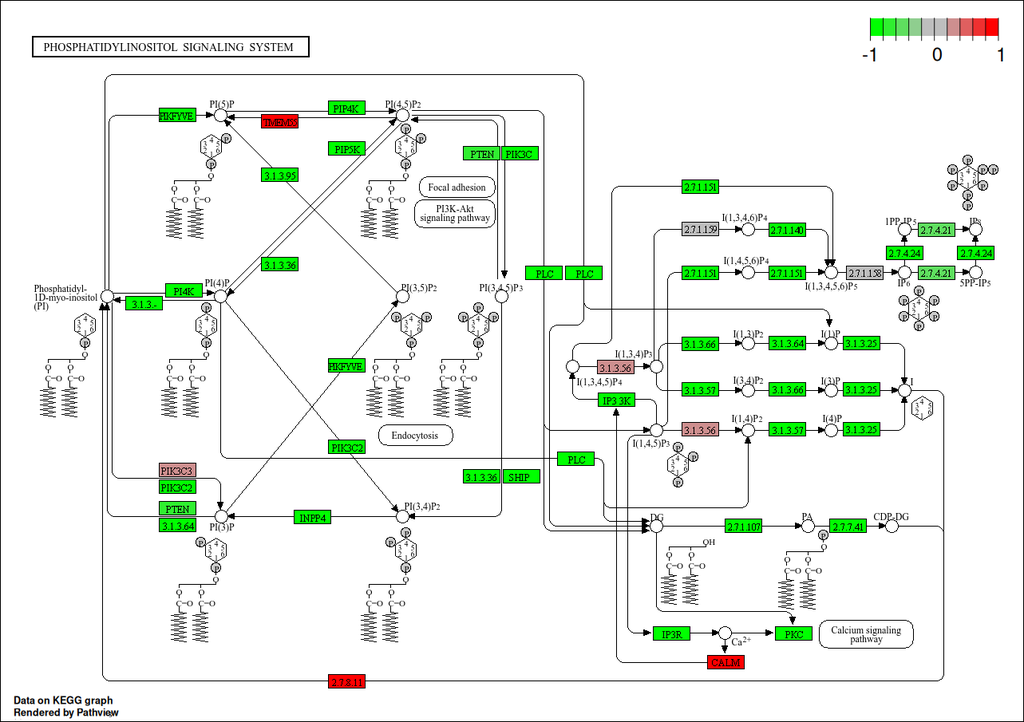

Phosphatidylinositol signaling system

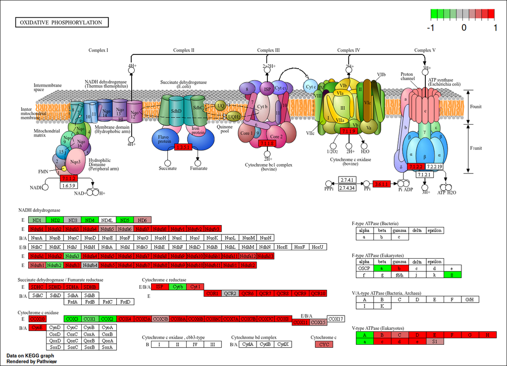

Oxidative phosphorylation

De figuur laat duidelijke activatie zien van mitochondriale genen verspreid over complex I tot en met complex V. Deze upregulatie van oxidatieve fosforylering wijst op verhoogde ATP-productie en een grotere energiebehoefte in cellen die zijn blootgesteld aan EV’s.

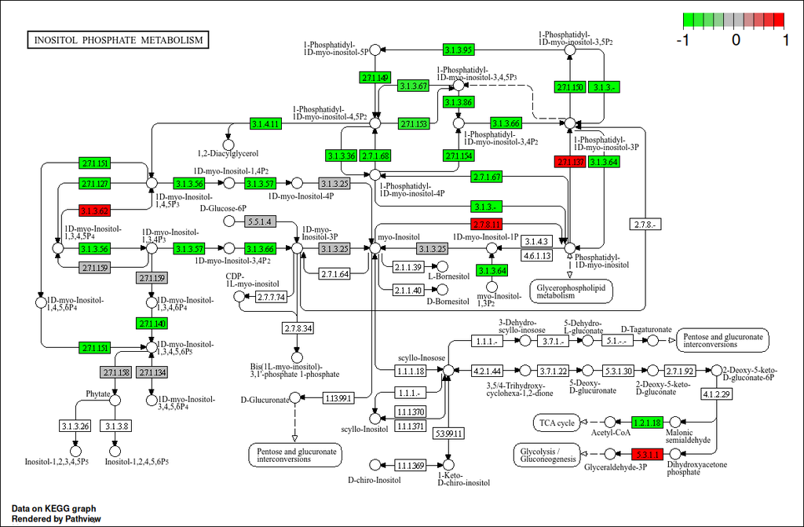

Inositol phosphate metabolism

# Mens

```r
df_genes_mens <- data.frame(
  symbol = names(gene_ranks_crl_extra),
  stat = gene_ranks_crl_extra
)
df_mapped_mens <- df_genes %>%
  left_join(
    AnnotationDbi::select(org.Hs.eg.db,
                          keys = df_genes$symbol,
                          columns = c("ENTREZID", "SYMBOL"),
                          keytype = "SYMBOL"),
    by = c("symbol" = "SYMBOL")
  ) %>%
  filter(!is.na(ENTREZID))


geneList_Mens <- df_mapped_mens$stat
names(geneList_Mens) <- df_mapped_mens$ENTREZID
```

# Coronavirus

```r
term <- c(
  "Coronavirus disease - COVID-19 - Mus musculus (house mouse)")
gsea_kegg@result[gsea_kegg@result$Description %in% term, ]
```

```
##  [1] ID              Description     setSize         enrichmentScore
##  [5] NES             pvalue          p.adjust        qvalue
##  [9] rank            leading_edge    core_enrichment
## <0 rows> (or 0-length row.names)
```

```r
setwd("imgs_trans/corona")
pathview(
  gene.data = geneList_1,
  pathway.id = "mmu05171",
  species = "mmu",
  out.suffix = "Corno_1",
  low=list(gene="magenta"),
  high = list(gene="green")
)
```

```
## Info: Working in directory /home/Jonkerjas/Documents/bioinf/jaar_2/omics/omic_epithelial_cell_repair/Logfiles/imgs_trans/corona
```

```
## Info: Writing image file mmu05171.Corno_1.png
```

```r
pathview(
  gene.data = sol_gen,
  pathway.id = "mmu05171",
  species = "mmu",
  out.suffix = "Corno_2",
  low=list(gene="magenta"),
  high = list(gene="green")
)
```

```
## Info: Working in directory /home/Jonkerjas/Documents/bioinf/jaar_2/omics/omic_epithelial_cell_repair/Logfiles/imgs_trans/corona
```

```
## Info: Writing image file mmu05171.Corno_2.png
```

```r
pathview(
  gene.data = geneList_3,
  pathway.id = "mmu05171",
  species = "mmu",
  out.suffix = "Corno_3",
  low=list(gene="magenta"),
  high = list(gene="green")
)
```

```
## Info: Working in directory /home/Jonkerjas/Documents/bioinf/jaar_2/omics/omic_epithelial_cell_repair/Logfiles/imgs_trans/corona
```

```
## Info: Writing image file mmu05171.Corno_3.png
```

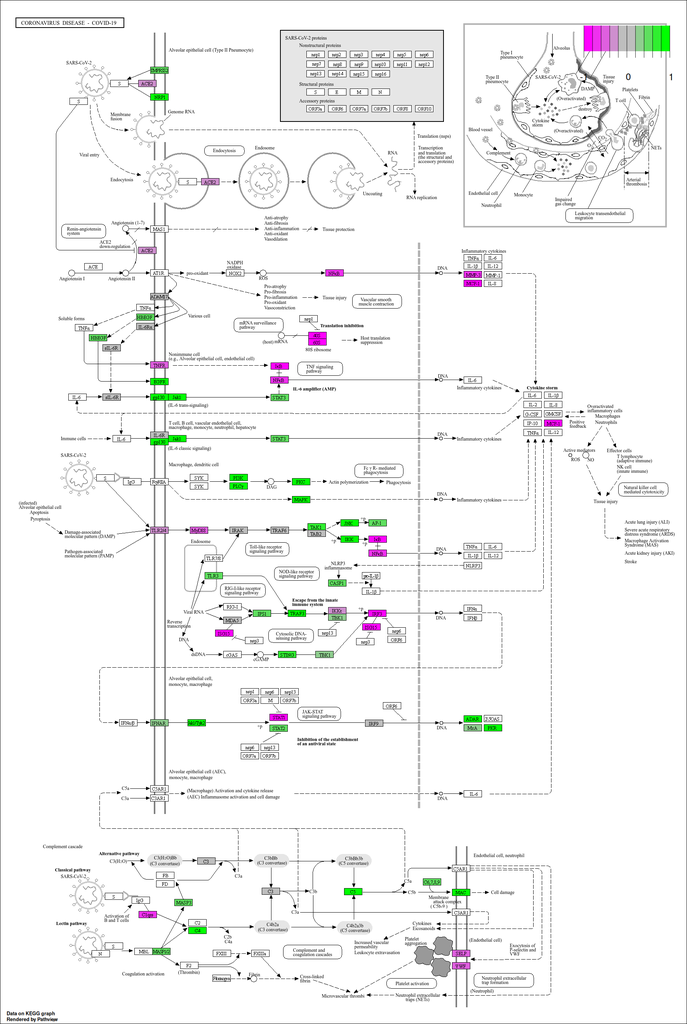

Corona in crt vs evs

Conclusie (Control vs. Extracellular Vesicles)

Daarnaast zijn ook enkele antivirale genen zoals OAS1, MX1 en IFITM1 verhoogd tot expressie gekomen, wat wijst op een versterkte antivirale verdediging door EV-behandeling.

Deze resultaten suggereren dat EV’s een sterke immuunstimulerende werking hebben: ze activeren zowel ontstekings- als antivirale routes. Dit kan nuttig zijn in situaties waarin een immuunreactie gewenst is, maar kan ook gepaard gaan met risico op overmatige ontsteking als dit niet goed gereguleerd wordt.

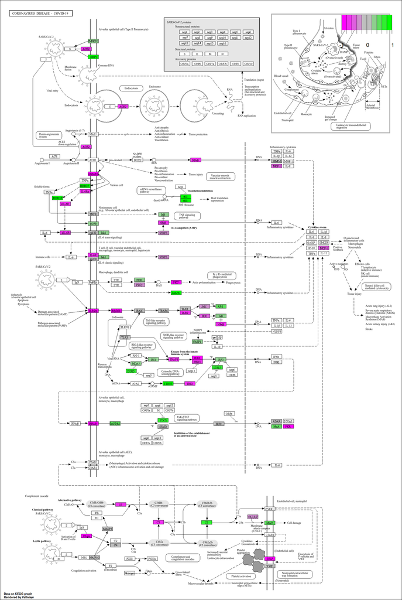

Corona in crt vs sfs

Conclusie

Ook valt op dat genen betrokken bij complementactivatie en stolling, zoals C3, FGA en FGB, meer actief zijn, wat kan leiden tot weefselschade en ontstekingsproblemen.

Kortom, Soluble Factors zorgen voor een immuunrespons die uit balans is: de ontsteking wordt sterker, terwijl de bescherming tegen virussen en weefselschade afneemt. Dit kan bijdragen aan ziektemechanismen zoals die bij ernstige infecties worden gezien.

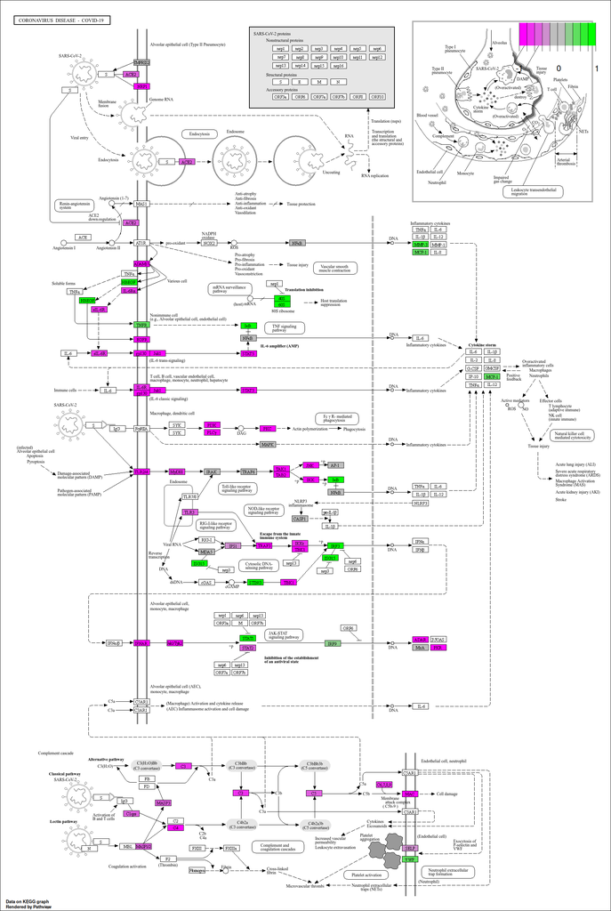

Corona in sfs vs evs

Conclusie (Extracellular Vesicles vs. Soluble Factors)

Deze resultaten suggereren dat EVs een beschermende rol kunnen spelen door ontsteking te remmen, antivirale afweer te versterken en weefselschade te beperken, in tegenstelling tot de pro-inflammatoire effecten die worden gezien bij SF’s.

# Vsd

https://bioconductor.org/packages/devel/bioc/vignettes/DESeq2/inst/doc/DESeq2.html#variance-stabilizing-transformation

```r
vsd<- vst(dds, blind = F)
ntd <- normTransform(dds)
```

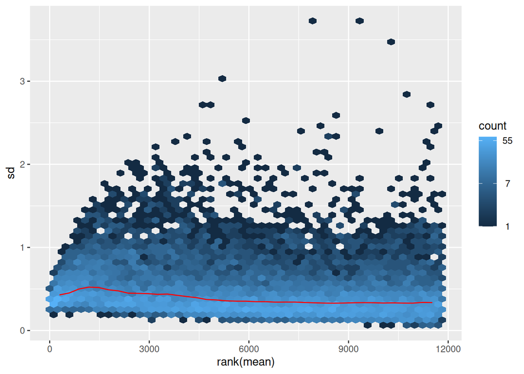

```r
meanSdPlot(assay(vsd))
```

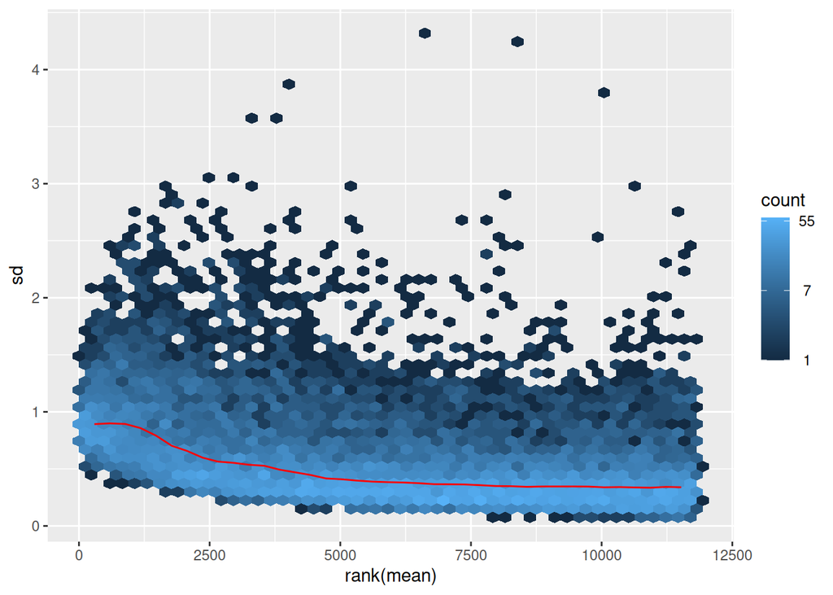

```r
meanSdPlot(assay(ntd))
```